# Analysez les ventes d'une librairie avec Python

```python
# Application des tests de Kolmogorov-Smirnov et Shapiro-Wilk à la colonne total_sales_of_customer
normality_test(sales_by_customer, 'total_sales_of_customer', 0.05)
```

```
Test de Kolmogorov-Smirnov: la variable total_sales_of_customer ne semble pas suivre une gaussienne (on rejette H0)
Test de Shapiro-Wilk: la variable total_sales_of_customer ne semble pas suivre une gaussienne (on rejette H0)
```

```
'Skewness: 1.160 | Excès de Kurtosis: 1.094 | KS Statistique: 1.000 | KS P-valeur: 0.000 | SW Statistique: 0.895 | SW P-valeur: 0.000'
```

Etant donné les résultats du test de Kolmogorov-Smirnov, et vu que le coefficient de corrélation de Pearson suppose que les deux variables sont normalement distribuées et qu'il existe une relation linéaire entre les deux, **on utilisera plutôt le coefficient de Spearman pour évaluer leur corrélation**.

```python
# Créer une fonction qui calcule le coefficient de corrélation des rangs de Spearman et la p-valeur associée
def spearman_correlation_test(df, df_x, df_y):
    n = len(df)

    # on calcule le rang de chaque valeur de la variable df_x
    df['ranks_x'] = df[df_x].rank(method='average')
    # Même chose pour la variable df_y
    df['ranks_y'] = df[df_y].rank(method='average')
    # on fait la somme des carrés des écarts entre les rangs de x et les rangs de y
    sum_of_squared_differences = ((df['ranks_x'] - df['ranks_y'])**2).sum()

    # Calcul du coef de spearman = (6 * la somme des carrés des écarts) divisée par n³-n
    spearman_r = 1 - (6*sum_of_squared_differences)/(n*(n**2-1))

    # calcul de la statistique t utilisée pour calculer la p-valeur
    t_statistic = spearman_r * np.sqrt((n-2)/(1-spearman_r**2))

    # On supprime la colonne créée dans notre dataframe puisqu'elle n'est plus utile
    df.drop(columns=['ranks_x', 'ranks_y'], inplace=True)

    # Calcul de la p-valeur associée au test, à comparer au seuil de signification (0.05)
    p_value_two_sided = 2 * (1 - stats.t.cdf(abs(t_statistic), n - 2))
    return f'Coefficient de corrélation de Spearman: {round(spearman_r,3)}, p-valeur: {p_value_two_sided}'

# Utiliser la fonction pour calculer le coefficient de spearman et renvoyer une p-valeur
spearman_correlation_test(sales_by_customer, 'age', 'total_sales_of_customer')
```

```
'Coefficient de corrélation de Spearman: -0.184, p-valeur: 0.0'
```

```python
# Même calcul en utlisant cette fois la fonction scipy.stats.spearmanr()
spearman_corr, p_value = stats.spearmanr(sales_by_customer['age'], sales_by_customer['total_sales_of_customer'])
print('Coefficient de corrélation de Spearman: %.3f' % spearman_corr)
print('p-valeur: %.3f' % p_value)
```

```
Coefficient de corrélation de Spearman: -0.185
p-valeur: 0.000
```

Le coefficient de corrélation de Spearman montre une **corrélation négative assez faible**, mais dont la significativité est toutefois confirmée par la faiblesse de la p-valeur qui est très proche de 0. Il semble donc y avoir un lien, bien que faible, entre l'âge et les dépenses en livres.

Comment l'interpréter ? Une interprétation possible est que l'on achète beaucoup de livres lorsque l'on fait des études (plus par nécessité), que l'on en achète davantage quand on entre dans la vie active et jusqu'à la cinquantaine (plutôt par plaisir), mais qu'au-delà des 50 ans d'autres centres d'intérêts prennent le pas sur la lecture.

```python
# Regrouper les données par âge et calculer, pour chaque âge, le montant total des achats des clients ayant cet âge
sales_by_age = sales_by_customer.groupby('age').agg({'total_sales_of_customer': 'sum'})
sales_by_age = sales_by_age.reset_index()
sales_by_age.columns = ['age', 'total_sales_of_clients_this_age']
sales_by_age.head()
```

|  | age | total_sales_of_clients_this_age |
| --- | --- | --- |
| 0 | 20 | 616418.15 |
| 1 | 21 | 180680.89 |
| 2 | 22 | 186791.83 |
| 3 | 23 | 181233.57 |
| 4 | 24 | 167388.08 |

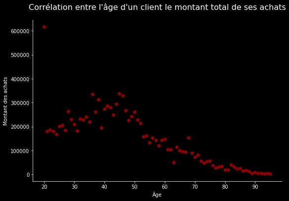

```python
# Visualiser la corrélation entre l'âge et le montant total des achats de l'ensemble des clients ayant cet âge
# On remarque que les clients de 20 ans se distinguent nettement, probablement parce qu'ils sont très nombreux
plt.figure(figsize=(9,6))
plt.scatter(sales_by_age['age'], sales_by_age['total_sales_of_clients_this_age'], color='darkred')
plt.title('Corrélation entre l\'âge d\'un client le montant total de ses achats', fontsize=16, pad=20)
plt.ylabel('Montant des achats')
plt.xlabel('Âge')
plt.gca().spines[['right', 'top']].set_visible(False)
plt.show()
```

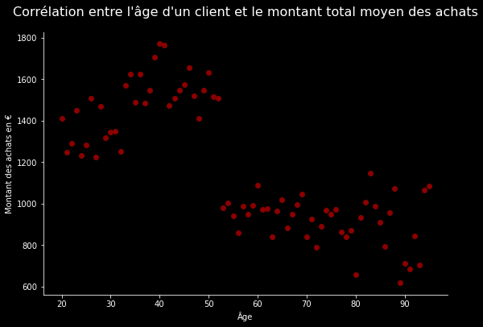

```python
# Même chose en utilisant le montant moyen des achats
# Cette fois on voit clairement une corrélation négative
average_sales_by_age = sales_by_customer.groupby('age').agg({'total_sales_of_customer': 'mean'})
average_sales_by_age = average_sales_by_age.reset_index()
average_sales_by_age.columns = ['age', 'average_sales_of_clients_this_age']
plt.figure(figsize=(9,6))
plt.scatter(average_sales_by_age['age'], average_sales_by_age['average_sales_of_clients_this_age'], color='darkred')
plt.title('Corrélation entre l\'âge d\'un client et le montant total moyen des achats', fontsize=16, pad=20)
plt.ylabel('Montant des achats en €')
plt.xlabel('Âge')
plt.gca().spines[['right', 'top']].set_visible(False)
plt.show()
```

Après avoir groupé les lignes par âge et calculé le montant total moyen des achats des clients pour chaque âge, on effectue un nouveau test et constate une corrélation négative beaucoup plus forte et toujours satistiquement significative.

```python
# Calculer le coefficient de corrélation des rangs de spearman sur le dataframe average_sales_by_age
spearman_correlation_test(average_sales_by_age, 'age', 'average_sales_of_clients_this_age')
```

```
'Coefficient de corrélation de Spearman: -0.728, p-valeur: 9.658940314238862e-14'
```

**Il est fréquent d'entendre que la non normalité d'une distribution n'est pas un frein à l'utilisation des tests paramétriques tant que le nombre d'individus dans les échantillons est grand**. De plus, lorsque la taille d'un échantillon est grande (plus de 30 observations), la distribution de l’échantillon se rapproche de la distribution normale grâce au **théorème central limite**. Par conséquent, nous allons également utiliser le coefficient de Pearson pour évaluer la corrélation.  
H0 = le coefficient de corrélation est égal à 0, les variables âge et montant total des achats sont indépendantes  
H1 = le coefficient de corrélation est différent de 0, les variables âge et montant total des achats ne sont pas indépendantes  
Si le coefficient de Pearson est différent de 0 et que la p-valeur associée au test est inférieure au seuil de signification (0.05), on rejette l'hypothèse nulle.

```python
# Créer une fonction qui renvoie le coefficient de corrélation de Pearson et la p-valeur associée (qui mesure la significativité du coefficient)
def pearson_correlation_test(df, df_x, df_y):
    n = len(df[df_x])
    x_mean = df[df_x].mean()
    y_mean = df[df_y].mean()
    x_standard_deviation = df[df_x].std()
    y_standard_deviation = df[df_y].std()
    covariance_x_y = ((df[df_x] - x_mean) * (df[df_y] - y_mean)).sum() / len(df)
    pearson_coef = covariance_x_y / (x_standard_deviation * y_standard_deviation)

    # calcul de la statistique t utilisée pour calculer la p-valeur
    t_statistic = pearson_coef * np.sqrt((n-2)/(1-pearson_coef**2))

    # Calcul de la p-valeur associée au test, à comparer au seuil de signification (0.05)
    # Le test t de Student est bilatéral car le coefficient de Pearson, compris entre -1 et 1, peut être positif ou négatif
    p_value_two_sided = 2 * (1 - stats.t.cdf(abs(t_statistic), n - 2))
    return f'Coefficient de corrélation de Pearson: {round(pearson_coef,3)}, p-valeur: {p_value_two_sided}'
```

```python
# Utiliser la fonction pour évaluer la corrélation entre l'âge d'un client et le montant total de ses achats
pearson_correlation_test(sales_by_customer, 'age', 'total_sales_of_customer')
```

```
'Coefficient de corrélation de Pearson: -0.188, p-valeur: 0.0'
```

### Etape 3.3 - Lien entre l'âge des clients et la fréquence d'achat

A présent, évaluons la corrélation entre l'âge des clients et la fréquence d'achat, de nouveau 2 variables quantitatives. Dans ce contexte on peut définir la fréquence d'achat comme suit:  
- Par le nombre total de sessions d'un client (puisqu'en l'occurrence une session débouche sur un achat au minimum) .  
- Par le nombre total d'achats effectués par un client.  
Nous prendrons en compte la deuxième définition et utiliserons, comme pour la corrélation précédente, le **coefficient de corrélation de Pearson** si les conditions suivantes sont respectées:  
**- Chaque variable suit une distribution normale**  
**- Au moins 20 individus dans l'échantillon (recommandé)**  
Autrement nous utiliserons le **coefficent de corrélation de rangs de Spearman**..

```python
# Créer un dataframe session affichant pour chaque client le nombre total de sessions dudit client
sessions  = df_without_outliers.groupby('client_id')['session_id'].nunique()
sessions = sessions.reset_index()
sessions.columns = ['client_id', 'customer_number_of_sessions']
sessions.head()
```

|  | client_id | customer_number_of_sessions |
| --- | --- | --- |
| 0 | 1 | 34 |
| 1 | 2 | 100 |
| 2 | 3 | 36 |
| 3 | 4 | 96 |
| 4 | 5 | 49 |

```python
# Grouper les données par client puis calculer le nombre total de produits achetés et récupérer les données dans un dataframe
total_number_of_products_bought = df_without_outliers.groupby('client_id').agg({'nb_of_products_bought_during_session': 'sum', 'age_group': 'first'})
total_number_of_products_bought = total_number_of_products_bought.reset_index()
total_number_of_products_bought.columns = ['client_id', 'total_number_of_purchases', 'age_group']
```

```python
# Fusionner sessions avec sales_by_customer pour obtenir un dataframe contenant à la fois le nombre de sessions d'un client, son âge et le CA total généré par ce même client
purchase_frequency = pd.merge(sessions, sales_by_customer, on='client_id').merge(total_number_of_products_bought, on='client_id')
purchase_frequency.head()
```

|  | client_id | customer_number_of_sessions | age | total_sales_of_customer | total_number_of_purchases | age_group |
| --- | --- | --- | --- | --- | --- | --- |
| 0 | 1 | 34 | 69 | 629.02 | 79 | 60 and over |
| 1 | 2 | 100 | 48 | 2340.72 | 470 | 40-49 |
| 2 | 3 | 36 | 45 | 1006.55 | 186 | 40-49 |
| 3 | 4 | 96 | 60 | 1987.63 | 146 | 60 and over |
| 4 | 5 | 49 | 30 | 2819.30 | 403 | 30-39 |

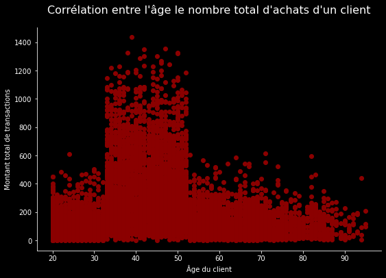

```python
# Visualiser la corrélation entre l'âge et le nombre total d'achats/transactions d'un client à l'aide d'un nuage de points
plt.figure(figsize=(9,6))
plt.scatter(purchase_frequency['age'], purchase_frequency['total_number_of_purchases'], color='darkred')
plt.title('Corrélation entre l\'âge le nombre total d\'achats d\'un client', fontsize=16, pad=20)
plt.ylabel('Montant total de transactions')
plt.xlabel('Âge du client')
plt.gca().spines[['right', 'top']].set_visible(False)
plt.show()
```

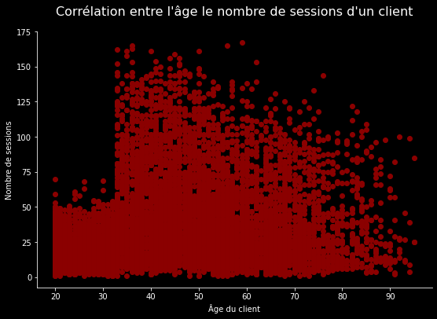

```python
# Visualiser la corrélation entre l'âge et le nombre total de sessions d'un client à l'aide d'un nuage de points
plt.figure(figsize=(9,6))
plt.scatter(purchase_frequency['age'], purchase_frequency['customer_number_of_sessions'], color='darkred')
plt.title('Corrélation entre l\'âge le nombre de sessions d\'un client', fontsize=16, pad=20)
plt.ylabel('Nombre de sessions')
plt.xlabel('Âge du client')
plt.gca().spines[['right', 'top']].set_visible(False)
plt.show()
```

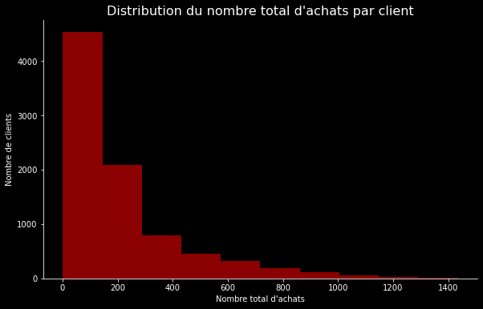

```python
# On a vu précédemment que la variable âge ne suit pas une distribution normale
# Visualisons la distribution de la variable nombre total d'achats
plt.figure(figsize=(9,6))
ax = purchase_frequency['total_number_of_purchases'].hist(color='darkred')
plt.title('Distribution du nombre total d\'achats par client', fontsize=16)
plt.xlabel('Nombre total d\'achats')
plt.ylabel('Nombre de clients')
plt.grid(False)
ax.spines[['top', 'right']].set_visible(False)



plt.tight_layout(pad=3.0)
```

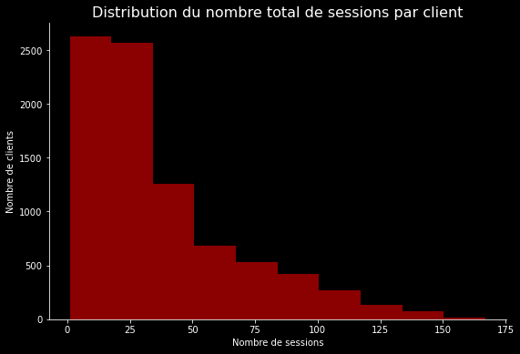

```python
# On visualise également celle de la variable nombre total de sessions
plt.figure(figsize=(9,6))
ax = purchase_frequency['customer_number_of_sessions'].hist(color='darkred')
plt.title('Distribution du nombre total de sessions par client', fontsize=16)
plt.xlabel('Nombre de sessions')
plt.ylabel('Nombre de clients')
plt.grid(False)
ax.spines[['top', 'right']].set_visible(False)
plt.show()
```

```python
# Tester la normalité de la distribution de la variable age
normality_test(purchase_frequency, 'age', 0.05)
```

```
Test de Kolmogorov-Smirnov: la variable age ne semble pas suivre une gaussienne (on rejette H0)
Test de Shapiro-Wilk: la variable age ne semble pas suivre une gaussienne (on rejette H0)
```

```
'Skewness: 0.362 | Excès de Kurtosis: -0.633 | KS Statistique: 1.000 | KS P-valeur: 0.000 | SW Statistique: 0.962 | SW P-valeur: 0.000'
```

```python
# Tester la normalité de la distribution de total_number_of_purchases
normality_test(purchase_frequency, 'total_number_of_purchases', 0.05)
```

```
Test de Kolmogorov-Smirnov: la variable total_number_of_purchases ne semble pas suivre une gaussienne (on rejette H0)
Test de Shapiro-Wilk: la variable total_number_of_purchases ne semble pas suivre une gaussienne (on rejette H0)
```

```
'Skewness: 1.900 | Excès de Kurtosis: 3.816 | KS Statistique: 0.995 | KS P-valeur: 0.000 | SW Statistique: 0.784 | SW P-valeur: 0.000'
```

```python
# Tester la normalité de la distribution de customer_number_of_sessions
normality_test(purchase_frequency, 'customer_number_of_sessions', 0.05)
```

```
Test de Kolmogorov-Smirnov: la variable customer_number_of_sessions ne semble pas suivre une gaussienne (on rejette H0)
Test de Shapiro-Wilk: la variable customer_number_of_sessions ne semble pas suivre une gaussienne (on rejette H0)
```

```
'Skewness: 1.356 | Excès de Kurtosis: 1.334 | KS Statistique: 0.990 | KS P-valeur: 0.000 | SW Statistique: 0.845 | SW P-valeur: 0.000'
```

Les deux variables ne sont pas normalement distribuées. On utilisera à nouveau le **coefficient de Spearman** pour évaluer la corrélation.

```python
# Evaluer, à l'aide du coefficient de corrélation des rangs de Spearman, la corrélation entre l'âge d'un client et le nombre total de produits achetés
# puis celle entre l'âge d'un client et le nombre de sessions
spearman_corr, p_value = stats.spearmanr(purchase_frequency['age'], purchase_frequency['total_number_of_purchases'])
print('Lien entre âge et nombre total de produits achetés => coef de Spearman: %.3f' % spearman_corr, '| p-valeur: %.3f' % p_value)

spearman_corr, p_value = stats.spearmanr(purchase_frequency['age'], purchase_frequency['customer_number_of_sessions'])
print('Lien entre âge et nombre total de sessions => Coef de Spearman: %.3f' % spearman_corr, '| p-valeur: %.3f' % p_value)
```

```
Lien entre âge et nombre total de produits achetés => coef de Spearman: 0.034 | p-valeur: 0.002
Lien entre âge et nombre total de sessions => Coef de Spearman: 0.212 | p-valeur: 0.000
```

```python
# Même chose en utilisant la fonction créée précédemment
print('âge et nombre total de produits achetés:', spearman_correlation_test(purchase_frequency, 'age', 'total_number_of_purchases'))
print('âge et nombre total de sessions:', spearman_correlation_test(purchase_frequency, 'age', 'customer_number_of_sessions'))
```

```
âge et nombre total de produits achetés: Coefficient de corrélation de Spearman: 0.034, p-valeur: 0.001416904674418351
âge et nombre total de sessions: Coefficient de corrélation de Spearman: 0.212, p-valeur: 0.0
```

```python
# On vérifie ce que cela donne avec le coefficient de corrélation de Pearson
pearson_correlation_test(purchase_frequency, 'age', 'total_number_of_purchases')
```

```
'Coefficient de corrélation de Pearson: -0.046, p-valeur: 2.1747084142154094e-05'
```

```python
# On vérifie ce que cela donne avec le coefficient de corrélation de Pearson mais en utilisant le nombre total de sessions
pearson_correlation_test(purchase_frequency, 'age', 'customer_number_of_sessions')
```

```
'Coefficient de corrélation de Pearson: 0.164, p-valeur: 0.0'
```

Le coefficient de corrélation de Spearman montre une corrélation positive très faible dans le premier cas et faible dans le deuxième. Cependant, dans les deux cas, la p-valeur est très largement inférieure au seuil de signification de 5 %. Par conséquent, et **bien que très faible**, on peut dire qu'**il existe une corrélation statistiquement significative** entre l'âge et la fréquence d'achat.

Voyons à présent si la corrélation est visuellement plus parlante en groupant par âge.

```python
# Regrouper les données par âge et calculer, pour chaque âge, le nombre total moyen de sessions et d'achats ainsi que le montant total moyen dépensé des clients ayant cet âge
sessions_purchases_grouped_by_age = purchase_frequency.groupby('age').agg({'customer_number_of_sessions': 'mean', 'total_number_of_purchases': 'mean', 'total_sales_of_customer': 'mean'})
sessions_purchases_grouped_by_age = sessions_purchases_grouped_by_age.reset_index()
sessions_purchases_grouped_by_age.columns = ['age', 'average_nb_of_sessions_of_clients_this_age', 'average_nb_of_purchases_of_clients_this_age', 'average_sales_of_clients_this_age' ]
sessions_purchases_grouped_by_age.head()
```

|  | age | average_nb_of_sessions_of_clients_this_age | average_nb_of_purchases_of_clients_this_age | average_sales_of_clients_this_age |
| --- | --- | --- | --- | --- |
| 0 | 20 | 20.036613 | 94.347826 | 1410.567849 |
| 1 | 21 | 18.034483 | 80.075862 | 1246.075103 |
| 2 | 22 | 18.386207 | 86.331034 | 1288.219517 |
| 3 | 23 | 19.904000 | 93.088000 | 1449.868560 |
| 4 | 24 | 18.205882 | 95.882353 | 1230.794706 |

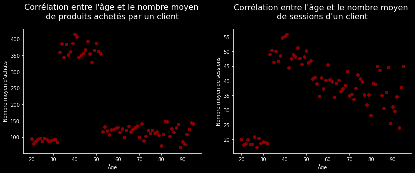

```python
# Visualiser la corrélation entre l'âge et la fréquence d'achat, exprimée par le nombre total d'achats des clients ayant un âge donné
# puis par le nombre total de sessions de ces mêmes clients
plt.figure(figsize=(18,18))

plt.subplot(4,3,1)
plt.scatter(sessions_purchases_grouped_by_age['age'], sessions_purchases_grouped_by_age['average_nb_of_purchases_of_clients_this_age'], color='darkred')
plt.title('Corrélation entre l\'âge et le nombre moyen \nde produits achetés par un client', fontsize=16, pad=20)
plt.ylabel('Nombre moyen d\'achats')
plt.xlabel('Âge')
plt.gca().spines[['right', 'top']].set_visible(False)

plt.subplot(4,3,2)
plt.scatter(sessions_purchases_grouped_by_age['age'], sessions_purchases_grouped_by_age['average_nb_of_sessions_of_clients_this_age'], color='darkred')
plt.title('Corrélation entre l\'âge et le nombre moyen \nde sessions d\'un client', fontsize=16, pad=20)
plt.ylabel('Nombre moyen de sessions')
plt.xlabel('Âge')
plt.gca().spines[['right', 'top']].set_visible(False)

plt.tight_layout(pad=3.0)
```

```python
# # Si on applique le test de Spearman, le résultat montre que l'on ne peut pas rejeter l'hypothèse nulle selon laquelle les variables âge et nombre moyen de sessions
# sont independantes. En effet, le coefficient est proche de 0 et la p-valeur est proche de 1
spearman_correlation_test(sessions_purchases_grouped_by_age, 'age', 'average_nb_of_sessions_of_clients_this_age')
```

```
'Coefficient de corrélation de Spearman: -0.003, p-valeur: 0.97854118091275'
```

```python
# Même constat entre les variables âge et nombre moyen de produits achetés : le coefficient est proche de 0 et la p-valeur est élevée
spearman_correlation_test(sessions_purchases_grouped_by_age, 'age', 'average_nb_of_purchases_of_clients_this_age')
```

```
'Coefficient de corrélation de Spearman: -0.049, p-valeur: 0.6711786057747684'
```

### Etape 3.4 - Lien entre l'âge des clients et la taille du panier moyen

Etant donné qu'une transaction (ou achat) = un produit, et qu'une session peut englober plusieurs achats/produits, on peut dire qu'une session correspond à un panier. Nous allons donc calculer, pour chaque client, le montant de son panier moyen. Concernant l'âge, nous allons utiliser les tranches d'âge pour évaluer la corrélation.  
La variable tranche d'âge est qualitative et la variable taille du panier moyen est quantitative. Nous visualiserons la corrélation à l'aide d'un boxplot et **testerons la significativité de celle-ci avec l'ANOVA si les conditions de validité du test sont remplies, autrement nous effectuerons les test de Kruskal-Wallis**.

```python
# Calcul du panier moyen de chaque client en divisant le chiffre d'affaires total du client par le nombre de sessions (de paniers) de ce même client
purchase_frequency['average_order_value'] = purchase_frequency['total_sales_of_customer'] / purchase_frequency['customer_number_of_sessions']
purchase_frequency.head()
```

|  | client_id | customer_number_of_sessions | age | total_sales_of_customer | total_number_of_purchases | age_group | average_order_value |
| --- | --- | --- | --- | --- | --- | --- | --- |
| 0 | 1 | 34 | 69 | 629.02 | 79 | 60 and over | 18.500588 |
| 1 | 2 | 100 | 48 | 2340.72 | 470 | 40-49 | 23.407200 |
| 2 | 3 | 36 | 45 | 1006.55 | 186 | 40-49 | 27.959722 |
| 3 | 4 | 96 | 60 | 1987.63 | 146 | 60 and over | 20.704479 |
| 4 | 5 | 49 | 30 | 2819.30 | 403 | 30-39 | 57.536735 |

```python
# Calcul du panier moyen tous clients confondus (à l'exception bien sûr des 4 gros outliers)
average_basket = purchase_frequency['average_order_value'].mean()
average_basket
```

```
40.402796386422054
```

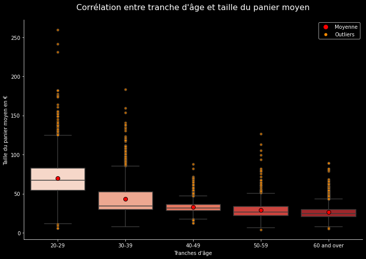

```python
# Visualiser la corrélation entre le groupe d'âge et la taille du panier moyen
plt.figure(figsize=(12, 8))
palette = sns.color_palette("Reds", n_colors=5).as_hex()[::]
meanprops = dict(marker='o', markersize=8, markeredgecolor='black', markerfacecolor='red')
mean_marker = mlines.Line2D([], [], color='red', marker='o', linestyle='None', markersize=8, label='Moyenne')

flierprops = dict(marker='o', markersize=5, markerfacecolor='darkorange', linestyle='none', alpha=0.7)
outliers_marker = mlines.Line2D([], [], color='darkorange', marker='o', linestyle='None', markersize=5, label='Outliers')

sns.boxplot(x='age_group', y='average_order_value', data=purchase_frequency, order=['20-29', '30-39', '40-49', '50-59', '60 and over'], palette=palette, meanprops=meanprops, showmeans=True, flierprops=flierprops)
plt.title('Corrélation entre tranche d\'âge et taille du panier moyen', fontsize=16, pad=20)
plt.xlabel('Tranches d\'âge')
plt.ylabel('Taille du panier moyen en €')
sns.despine()
plt.legend(handles=[mean_marker, outliers_marker])
plt.show()
```

On remarque des différences dans la variance de la taille des paniers moyens d'une tranche d'âge à une autre. Le panier moyen des clients âgés de 20 à 29 ans est globalement plus élevé que dans toutes les autres tranches d'âge. Viennent ensuite les 30-39 ans. Il semble donc y avoir une corrélation négative entre l'âge (ici exprimé en tranche d'âge) et la taille du panier moyen. Mais cette corrélation est-elle statistiquement significative ? Comparons les paniers moyens de ces différentes tranches d'âge par l'ANOVA à un facteur.  
**On pose les hypothèses suivantes**:  
H0 = Les paniers moyens sont identiques et par conséquent l'âge d'un client n'a aucun impact sur le montant moyen du panier.  
H1 = Le panier moyen d'au moins une tranche d'âge diffère des autres paniers moyens et par conséquent on rejette l'hypothèse nulle.

Il nous faut **tester les conditions de validité suivantes avant d'effectuer l'ANOVA** :  
-Les mesures sont indépendantes  
-Les échantillons ont des variances égales  
-Les résidus suivent une distribution normale (supposée ou vérifiée)  
-Au moins 20 individus dans le dispositif, ou normalité des résidus supposée ou vérifiée  
Les mesures sont indepéndantes. **Nous allons tester l'égalité des variances avec le test de Levene et la normalité des résidus avec Shapiro-Wilk.** .  
**Hypothèses avec un seuil de signification de 0.05:**  
H0 = Les variances sont égales | les résidus suivent une distribution normale  
H1 = Au moins une variance diffère des autres | les résidus ne suivent pas une distribution normale

```python
# Créez une liste de listes, où chaque sous-liste contient toutes les valeurs de 'average_order_value' pour un âge donné
samples = [list(purchase_frequency.loc[purchase_frequency['age_group'] == age_group, 'average_order_value']) for age_group in purchase_frequency['age_group'].unique()]

# Appliquez le test de Levene du module scipy.stats
w, p_value = stats.levene(*samples)

print(f"Levene's Test W-statistic : {w}")
print(f"Levene's Test P-value : {p_value}")
```

```
Levene's Test W-statistic : 359.3600864847125
Levene's Test P-value : 1.5025187799646024e-286
```

```python
# créer une fonction qui calcule les résidus et effectue le test de normalité
def intra_class_residuals(df, categ, categ_values, alpha):
    total_count = len(df)
    # récupérer dans un array les résidus (en l'occurrence les écarts à la moyenne intra groupe)
    residuals = np.empty(total_count)
    for group in df[categ].unique():
        group_df = df.loc[df[categ] == group]
        group_mean = group_df[categ_values].mean()

        # Calculer les résidus pour ce groupe
        group_residuals = group_df[categ_values] - group_mean

        # Ajouter les résidus de ce groupe au tableau de résidus
        residuals[group_df.index] = group_residuals

    if len(residuals) > 5000:
        random_sample = np.random.choice(residuals, 2000, replace=False)
        statistic, p_value = stats.shapiro(random_sample)

    if p_value > alpha:
        print(f'Test de Shapiro-Wilk: les résidus semblent suivre une gaussienne (on ne rejette pas H0)')
    else:
        print(f'Test de Shapiro-Wilk: les résidus ne semblent pas suivre une gaussienne (on rejette H0)')

    return f'Statistique: {statistic} | P-valeur: {p_value}'
```

```python
# tester la normalité des résidus avec la fonction
intra_class_residuals(purchase_frequency, 'age_group', 'average_order_value', 0.05)
```

```
Test de Shapiro-Wilk: les résidus ne semblent pas suivre une gaussienne (on rejette H0)
```

```
'Statistique: 0.8483839631080627 | P-valeur: 3.993798714218231e-40'
```

Le test de Levene renvoie deux valeurs : la statistique W et la p-valeur. Plus la statistique W est élevée plus la différence entre les variance est grande.  
Si la p-valeur, probabilité d'observer une statistique W aussi extrême sous l'hypothèse nulle, est inférieure au seuil de signification (ici = 0,05), on rejette l’hypothèse nulle selon laquelle les variances sont égales. Dans notre cas la p-valeur est très proche de 0.  
Concernant les résidus, la p-valeur renvoyée par le test de Shapiro-Wilk est là encore inférieure au seuil de signification alpha. Par conséquent **on rejette l’hypothèse nulle dans les deux cas. On utilisera le test de Kruskal-Wallis**.

```python
#Créer une fonction qui effectue le test de Kruskal-Wallis
def kruskal_wallis(df, variable_a, variable_b, alpha):

    # On attribue un rang à chaque valeur de la colonne variable_b après que celles-ci aient été triées par ordre croissant (la fonction rank effectue le tri)
    # Si plusieurs valeurs sont égales on leur attribue un rang égal à la moyenne des rangs
    # Ex : Si les valeurs aux rangs 3, 4 et 5 sont égales, elles auront toutes les trois le rang 4 car (3+4+5)/3 = 4
    df['ranks'] = df[variable_b].rank(method='average')

    # Calcul de la somme des rangs pour chaque groupe
    Ri_sum = df.groupby(variable_a)['ranks'].sum()

    df = df.drop(columns='ranks')

    # Nombre total d'observations dans l'ensemble des groupes
    N = len(df)

    # K est le nombre de valeurs uniques de la variable indépendante
    k = df[variable_a].nunique()

    # Calcul la statistique H
    H = (12 / (N * (N + 1))) * sum((Ri_sum[i] ** 2) / len(df.loc[df[variable_a] == i]) for i in df[variable_a].unique()) - 3 * (N + 1)

    # Calcul des degrés de liberté
    degrees_of_freedom = k - 1

    # Le niveau de signification choisi
    alpha = alpha

    # Calcul, à l'aide du module stats de scipy, de la valeur critique pour un niveau de confiance de 1 - alpha et n degrés de liberté
    critical_value = stats.chi2.ppf(1 - alpha, degrees_of_freedom)

    # calcul de la p-valeur
    p_value = 1 - stats.chi2.cdf(H, degrees_of_freedom)

    return f'''Statistique H : {H}, Valeur critique : {critical_value}, P-valeur : {p_value}'''
```

```python
# Utiliser la fonction et comparer avec le résultat de la fonction stats.kruskal de scipy
kruskal_wallis(purchase_frequency, 'age_group', 'average_order_value', 0.05)
```

```
'Statistique H : 4320.580835235676, Valeur critique : 9.487729036781154, P-valeur : 0.0'
```

```python
# Vérifier les résultats en utilisant la fonction scipy.stats.kruskal()

# Créer des sous-ensembles de données pour chaque tranche d'âge
group1 = purchase_frequency[purchase_frequency['age_group'] == '20-29']['average_order_value']
group2 = purchase_frequency[purchase_frequency['age_group'] == '30-39']['average_order_value']
group3 = purchase_frequency[purchase_frequency['age_group'] == '40-49']['average_order_value']
group4 = purchase_frequency[purchase_frequency['age_group'] == '50-59']['average_order_value']
group5 = purchase_frequency[purchase_frequency['age_group'] == '60 and over']['average_order_value']

result = stats.kruskal(group1,group2,group3,group4,group5)
print("Statistique H de Kruskal-Wallis :", result.statistic)
print("Valeur p :", result.pvalue)
```

```
Statistique H de Kruskal-Wallis : 4320.580836256011
Valeur p : 0.0
```

La statistique H est très largement supérieure à la valeur critique du test. Surtout, la p-valeur renvoyée est très proche de 0 (ici arrondie à 0 par l'ordinateur).  
**On rejette l'hypothèse nulle selon laquelle il n'y a pas de différence significative entre la taille des paniers moyens d'une tranche d'âge à une autre**. L'âge semble avoir un effet sur la taille du panier moyen d'un client.

```python
# Créer un dataframe contenant la taille du panier moyen de chaque tranche d'âge
grouped_by_age_group = purchase_frequency.groupby('age_group')['average_order_value'].mean()
grouped_by_age_group = grouped_by_age_group.reset_index()
grouped_by_age_group.columns = ['age_group', 'age_group_average_order_value']
grouped_by_age_group
```

|  | age_group | age_group_average_order_value |
| --- | --- | --- |
| 0 | 20-29 | 69.648262 |
| 1 | 30-39 | 43.479534 |
| 2 | 40-49 | 33.002153 |
| 3 | 50-59 | 28.709195 |
| 4 | 60 and over | 26.494877 |

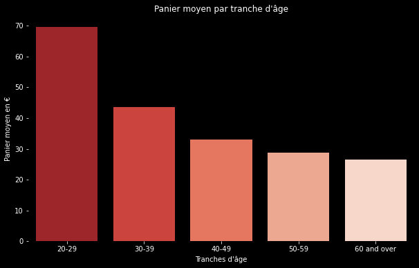

```python
# Visualiser la taille du panier moyen par tranche d'âge
plt.figure(figsize=(10, 6))
palette = sns.color_palette("Reds", n_colors=5).as_hex()[::-1]
sns.barplot(data=grouped_by_age_group, x='age_group', y='age_group_average_order_value', palette=palette)
plt.title('Panier moyen par tranche d\'âge')
plt.xlabel('Tranches d\'âge')
plt.ylabel('Panier moyen en €')
plt.box()
plt.show()
```

### Etape 3.5 - Lien entre l'âge et la catégorie de produits achetés

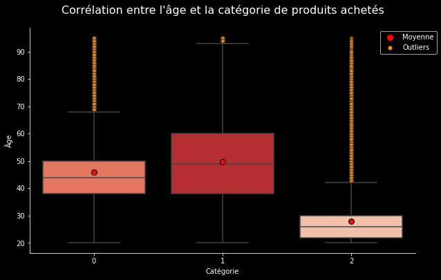

```python
# visualiser la corrélation entre l'âge et la catégorie de livres achetés à l'aide d'un boxplot
# Les acheteurs de produits de catégorie 2 sont généralement plus jeunes, les trois quarts ont à peine plus de 30 ans
plt.figure(figsize=(10, 6))

color1 = sns.color_palette("Reds", n_colors=3).as_hex()[::-1][0]
color2 = sns.color_palette("Reds", n_colors=3).as_hex()[::-1][1]
color3 = sns.color_palette("Reds", n_colors=3).as_hex()[::-1][2]

palette = {'0' : color2, '1' : color1, '2' : color3}
meanprops = dict(marker='o', markersize=8, markeredgecolor='black', markerfacecolor='red')
mean_marker = mlines.Line2D([], [], color='red', marker='o', linestyle='None', markersize=8, label='Moyenne')
flierprops = dict(marker='o', markersize=5, markerfacecolor='darkorange', linestyle='none', alpha=0.7)
outliers_marker = mlines.Line2D([], [], color='darkorange', marker='o', linestyle='None', markersize=5, label='Outliers')

sns.boxplot(x='categ', y='age', data=df_without_outliers, palette=palette, meanprops=meanprops, showmeans=True, flierprops=flierprops)
plt.title('Corrélation entre l\'âge et la catégorie de produits achetés', fontsize=16, pad=20)
plt.xlabel('Catégorie')
plt.ylabel('Âge')
sns.despine()
plt.legend(handles=[mean_marker,outliers_marker], bbox_to_anchor=(0.90, 1), loc='upper left')
plt.show()
```

Cette dernière corrélation implique la variable quantitative âge et la variable qualitative catégorie. Il s'agit d'évaluer le lien entre les variables en comparant l'âge moyen des clients dans les 3 catégories. Nous avons donc 3 moyennes à comparer. Sur le boxplot ci-dessus on constate de gros écarts entre ces moyennes. Il faut découvrir si ces écarts sont statistiquement significatifs. A nouveau, le choix entre le test Anova et le test de Kruskal-Wallis s'impose. Mais ici **nous choisirons le test Anova indépendamment des conditions de validité car il est fréquemment admis que l'ANOVA est robuste à la violation de la condition de non-normalité si la taille de l'échantillon est suffisamment grande.**  
Hypothèses:  
H0 : la moyenne d'âge des clients est identique dans les trois catégories.  
H1 : Au moins une moyenne diffère des autres.  
Seuil de signification : 0.05

```python
# Créer une fonction Anova qui renvoie le rapport de corrélation eta², la statistique F et la p-valeur
def Anova(df, categ, categ_values, alpha):
    # On calcule la moyenne générale
    grand_mean = df[categ_values].mean()
    inter_class_sum_of_squares = 0
    intra_class_sum_of_squares = 0
    total_sum_of_squares = 0
    total_count = len(df)
    group_counts = {}

    for group in df[categ].unique():
        group_df = df.loc[df[categ] == group]
        group_mean = group_df[categ_values].mean()
        group_size = len(group_df)
        group_counts[group] = group_size
        inter_class_sum_of_squares += group_size * (group_mean - grand_mean)**2
        intra_class_sum_of_squares += ((group_df[categ_values] - group_mean)**2).sum()
        total_sum_of_squares += ((group_df[categ_values] - grand_mean)**2).sum()

    # Calculer les degrés de libertés à mettre au dénominateur pour calculer les variances inter et intra groupes
    dof_inter_class = len(group_counts) - 1
    dof_intra_class = total_count - len(group_counts)

    inter_class_mean_squares = inter_class_sum_of_squares / dof_inter_class
    intra_class_mean_squares = intra_class_sum_of_squares / dof_intra_class

    f_statistic = inter_class_mean_squares / intra_class_mean_squares
    p_value = 1 - stats.f.cdf(f_statistic, dof_inter_class, dof_intra_class)

    # Proportion de la variance inter groupes par rapport à la variance totale
    eta_squared = inter_class_sum_of_squares / total_sum_of_squares

    critical_value = stats.f.ppf(1-alpha, dof_inter_class, dof_intra_class)

    return f'Eta² = {eta_squared} | F statistic = {f_statistic} | Critical Value = {critical_value} | P-value= {p_value}'
```

```python
# Utiliser la fonction créée plus haut pour tester le lien entre les deux variables
Anova(df_without_outliers, 'categ', 'age', 0.05)
```

```
'Eta² = 0.1102713562648539 | F statistic = 39705.51969324281 | Critical Value = 2.995746280044053 | P-value= 1.1102230246251565e-16'
```

```python
# Utiliser la fonction scipy.stats.f_oneway() pour vérifier si les résultats correspondent
categ0 = df_without_outliers[df_without_outliers['categ'] == '0']['age']
categ1 = df_without_outliers[df_without_outliers['categ'] == '1']['age']
categ2 = df_without_outliers[df_without_outliers['categ'] == '2']['age']
stats.f_oneway(categ0, categ1, categ2)
```

```
F_onewayResult(statistic=39705.51969324279, pvalue=0.0)
```

La statistique F, rapport entre la variance inter-groupe et la variance intra-groupe, est très largement supérieure à la valeur critique **ce qui nous pousse à rejeter l'hypothèse nulle. La p-valeur très proche de 0 confirme la significativité du résultat et soutient le choix du rejet**.

En fonction de leur âge, les clients feront plus d'achats dans une catégorie plutôt qu'une autre.

## Conclusion

Pour résumer, nous avons vu que:

- la tendance haussière du chiffre d'affaires s'est inversée après le pic de mars 2022
- les pics d'activité liés à la saisonnalité ont lieu chaque année en septembre (pic de ventes lié à la rentrée littéraire) et en octobre (chute des ventes, le soufflé rentrée littéraire retombe)
- la catégorie la plus performante est la catégorie 1
- la catégorie 2, catégorie de prédilection des clients jeunes, se distingue par ses prix élevés.
- la catégorie 0 représente 70% des produits commercialisés mais seulement 34 % du CA
- les femmes n'achètent pas plus que les hommes (et vice versa), mais elles sont légèrement plus nombreuses
- les 40-49 ans sont les clients qui génèrent le plus de CA, suivis par les 20-29 et 30-39
- le panier moyen des 20-29 ans est beaucoup plus élevé que dans les autres tranches d'âge mais ils achètent moins fréquemment
- la répartition du CA entre les différents produits suit le principe de Pareto
- 50% des clients génèrent 80% du CA

Eu égard aux informations récoltées, voici quelques recommandations qui pourraient bénéficier à l'entreprise:

- Diminuer le nombre de produits de catégorie 0 proposés, retirer les moins performants.  
- Se focaliser davantage sur ce qui fonctionne:

- les 20% de produits qui génèrent près de 80% du CA
- les 50% de clients qui génèrent près de 80% du CA
- les clients âgés entre 20 et 49 ans

- Vérifier si certains produits de catégorie 2 ne sont pas proposés à des prix exagérés, d'autant qu'ils sont achetés principalement par des jeunes (étudiants ?) et que ceux-ci n'ont globalement pas le même pouvoir d'achat que les clients des autres tranches d'âge.  
- Considérer la question suivante : "Quels produits pourraient séduire les plus de 50 ans ?"

## Analyses complémentaires

### Lien entre tranche d'âge et catégorie de produits achetés, deux variables qualitatives.

```python
# # Afficher le tableau de contingence entre age_group et categ où l'on peut voir le nombre de transactions par tranche d'âge et par catégorie
contingency_table = pd.crosstab(df_without_outliers['age_group'], df_without_outliers['categ'], margins=True)
contingency_table
```

| categ age_group | 0 | 1 | 2 | All |
| --- | --- | --- | --- | --- |
| 20-29 | 13365 | 23616 | 23630 | 60611 |
| 30-39 | 105507 | 38700 | 6763 | 150970 |
| 40-49 | 157479 | 51264 | 754 | 209497 |
| 50-59 | 65377 | 46917 | 743 | 113037 |
| 60 and over | 45553 | 60108 | 958 | 106619 |
| All | 387281 | 220605 | 32848 | 640734 |

**Les conditions de validité** pour effectuer le test sont respectées: les transactions sont indépendantes et les effectifs conjoints dans le tableau de contingence sont tous supérieurs à 5.

```python
# Utiliser la fonction créée précédemment pour générer le tableau des effectifs théoriques
expected_table = expected_values(contingency_table)
expected = expected_table.iloc[:-1, :-1]
expected
```

| categ age_group | 0 | 1 | 2 |
| --- | --- | --- | --- |
| 20-29 | 36635.0 | 20868.0 | 3107.0 |
| 30-39 | 91251.0 | 51979.0 | 7739.0 |
| 40-49 | 126626.0 | 72129.0 | 10740.0 |
| 50-59 | 68323.0 | 38918.0 | 5794.0 |
| 60 and over | 64444.0 | 36708.0 | 5465.0 |

```python
# Afficher le tableau des valeurs observées pour comparer avec celui au-dessus
observed_values = contingency_table.iloc[:-1, :-1]
observed_values
```

| categ age_group | 0 | 1 | 2 |
| --- | --- | --- | --- |
| 20-29 | 13365 | 23616 | 23630 |
| 30-39 | 105507 | 38700 | 6763 |
| 40-49 | 157479 | 51264 | 754 |
| 50-59 | 65377 | 46917 | 743 |
| 60 and over | 45553 | 60108 | 958 |

**Hypothèses**:  
H0 = Les variables catégorie de livres et groupe d'âge sont indépendantes.  
H1 = L'âge a une influence sur le choix de la catégorie de livres achetés.  
A présent, calculons la statistique du Khi-deux.

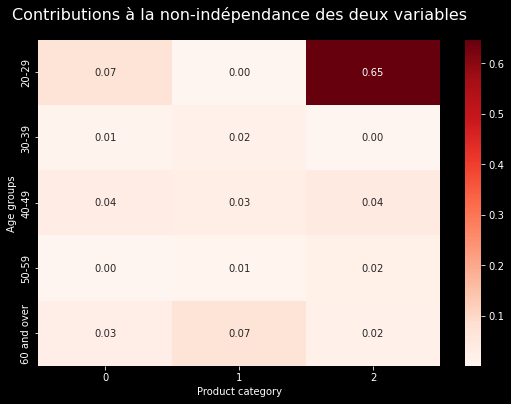

```
209631.7664643104
```

```python
# Calcul du Khi-deux avec la fonction chi_square_and_heatmap créée précédemment
# Les effectifs conjoints de catégorie 2 et 20-29 ans semblent contribuer fortement à la non indépendance de âge et catégorie
Chi_square_statistic = Chi_square_and_heatmap(contingency_table, expected_table,'Product category', 'Age groups')
Chi_square_statistic
```

Il faut à présent déterminer la valeur critique à laquelle nous allons comparer la statistique Khi-deux. Si cette dernière est supérieure à la valeur critique cela signifie que les écarts  
entre les valeurs observées et les valeurs attendues sont assez significatifs pour rejeter l'hypothèse nulle selon laquelle les deux varibales sont indépendantes.

```python
# On réutilise la fonction créée plus haut pour calculer la valeur critique et la p-valeur
Chi_square_critical_and_p_value(contingency_table, 0.05, Chi_square_statistic)
```

```
('Statistique du Khi-deux: 209631.77',
 'Valeur critique : 15.51',
 'P-valeur : 0.0')
```

```python
# De nouveau, on Vérifie le résultat en utilisant la fonction scipy.stats.chi2_contingency()
# On ne récupère que les valeurs du dataframe
observed_values_array = observed_values.values

chi2, p, dof, expected = stats.chi2_contingency(observed_values_array)

print(f"chi2 statistic:     {chi2}")
print(f"p-value:            {p}")
print(f"degrees of freedom: {dof}")
print("expected frequencies:") # Pour comparer avec les valeurs attendues générées plus haut par la fonction expected_values()
print(expected)
```

```
chi2 statistic:     209615.22101896504
p-value:            0.0
degrees of freedom: 8
expected frequencies:
[[ 36635.30995858  20868.3941464    3107.29589502]
 [ 91251.30330215  51979.03786907   7739.65882878]
 [126626.97415308  72129.9098924   10740.11595451]
 [ 68323.33292287  38918.68916742   5794.97790971]
 [ 64444.07966332  36708.9689247    5465.95141197]]
```

La statistique du Khi-deux étant très nettement supérieure à 15.51, et étant donné la très faible p-valeur (ici = 0), **on rejette l'hypothèse nulle**. Il semblerait que l'âge d'un client ait une influence sur le choix de la catégorie des livres achetés.

### Lien entre âge et fréquence d'achat.

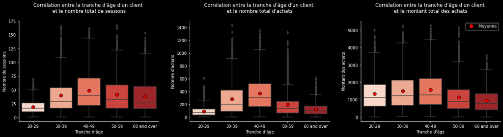

```python
# Visualiser la corrélation entre la variable tranche d'âge et le nombre d'achats à l'aide d'un boxplot
plt.figure(figsize=(18,18))
palette = sns.color_palette("Reds", n_colors=5).as_hex()[::]
meanprops = dict(marker='o', markersize=8, markeredgecolor='black', markerfacecolor='red')
mean_marker = mlines.Line2D([], [], color='red', marker='o', linestyle='None', markersize=8, label='Moyenne')
plt.subplot(4,3,1)
sns.boxplot(x='age_group', y='customer_number_of_sessions', data=purchase_frequency, order=['20-29', '30-39', '40-49', '50-59', '60 and over'], palette=palette, meanprops=meanprops, showmeans=True)
plt.title('Corrélation entre la tranche d\'âge d\'un client \net le nombre total de sessions', pad=20)
plt.xlabel('Tranche d\'âge')
plt.ylabel('Nombre de sessions')
sns.despine()

plt.subplot(4,3,2)
sns.boxplot(x='age_group', y='total_number_of_purchases', data=purchase_frequency, order=['20-29', '30-39', '40-49', '50-59', '60 and over'], palette=palette, meanprops=meanprops, showmeans=True)
plt.title('Corrélation entre la tranche d\'âge d\'un client \net le nombre total d\'achats', pad=20)
plt.xlabel('Tranche d\'âge')
plt.ylabel('Nombre d\'achats')
sns.despine()

plt.subplot(4,3,3)
sns.boxplot(x='age_group', y='total_sales_of_customer', data=purchase_frequency, order=['20-29', '30-39', '40-49', '50-59', '60 and over'], palette=palette, meanprops=meanprops, showmeans=True)
plt.title('Corrélation entre la tranche d\'âge d\'un client \net le montant total des achats', pad=20)
plt.xlabel('Tranche d\'âge')
plt.ylabel('Montant des achats')
sns.despine()
plt.legend(handles=[mean_marker])
plt.tight_layout(pad=3.0)
```

On remarque que la fréquence d'achat des clients de la tranche 20-29 ans est beaucoup plus faible que dans les autres tranches d'âge, mais globalement le montant total de leurs achats reste élevé, quasiment de même ampleur que celui des 40-49. Quant au plus de 60 ans, bien qu'ils se connectent assez régulièrement, ils achètent à peine plus de livres que les 20-29 ans. La tranche d'âge qui se distingue des autres par sa constance en termes de sessions, de nombre d'achats et de chiffre d'affaires généré est celle des 40-49 ans.

Quelle conclusion en tirer ? Une interprétation possible est que les client jeunes se connectent principalement par obligation, pour acheter les livres dont ils ont besoin pour leurs études, les 30-50 ans le font davantage pour le plaisir, mais qu'à partir de la cinquantaine d'autres centres d'intérêts prennent le pas sur la lecture.